# landslides-project-proposal slides

## Statistics 504 - Fall 2015

### Class Project Proposal

### Erich Seamon

### erichs@uidaho.edu

### http://webpages.uidaho.edu/erichs

### Title: " Exploring landslide likelihood across Washington using machine learning techniques"

### Introduction

The premise of this research will be to identify areas within the state of Washington that are susceptible to future landslides, based on the knowledge of past landslide events, terrain parameters, geological attributes, as well as daily meteorological data (precipitation, temperature, solar radiation, relative humidity , wind speed) (Abatzoglou, Brown, 2011).

Previous work by Ardizzone et al (2002), Ayalew and Yamagishi (2005), Ohlmacher and DAvid (2003), all used logistical regression as a classifer method for landslide analysis. To expand upon this work, this project will evaluate four differing models to predict landslide likelihood, based on historical and future climate scenario data sets:

-logistical regression,  
-support vector analysis,  
-random forest, and  
-neural networks

Under the above approach, landslide explanatory variables will be fitted or “trained” on a training data set of an observed landslide locations, with thematic data such as morphometric attributes (slope, aspect) as well as information on (geology, landuse, ). In this context, the misclassification rate for landslide potential, as measured using the test data, will be the primary quantitative measure for evaluating the predictive power the model (Efron and Gong, 1983; Efron and Tib- shirani, 1986).

### Data Sources

2007 and 2008 Landslide data for the state of Washington, containing over 52,000 observations, was accessed from the Washington Department of Natural Recreation (WA DNR). The data was provided as a downloadable .gdb file (geodatabase file).

#### Data Transformation before Analysis

The data was imported as a csv file - that was derived from the provided geodatabase file. This csv file contained over 52,000 observations, with latitude and longitude included as well. The csv file was transformed into a a pandas data frame, with text based categorical fields transformed to numeric values. From this pandas data frame, our feature columns (X) and our response variable (y).

From the 52,000+ landslide observations:

-3695 had dates. This is essential to match up with specific climate values for that day, and for the days surrounding this date.

### Statistical Design

For this project, a machine learning process flow will be developed that fits the aforementioned algorithms (Random Forest, SVM, Logistical Regression, Neural Networks). Then each model will be used for prediction and learning, as we iteratively identify optimal model tuning parameters.

After refining the model - then a series of climate variables for a set of future scenarios will be run against the model, which should provide a landslide confidence level based on future climatic outcomes.

```python
import PIL
import os,sys
import numpy as np
from PIL import Image
basewidth = 900
img = Image.open("/git/data/landslides/landslide_information_flow.jpg")
wpercent = (basewidth / float(img.size[0]))
hsize = int((float(img.size[1]) * float(wpercent)))
img = img.resize((basewidth, hsize), PIL.Image.ANTIALIAS)
img.save("/git/data/landslides/landslide_information_flow_refined.jpg")
```

[figure not shown]

```python
import os,sys
from PIL import Image
jpgfile = Image.open("/git/data/landslides/landslide_information_flow_refined.jpg")
jpgfile
```

## Preliminary Data Import and Analysis

```python
import matplotlib
%matplotlib nbagg

from pyproj import Proj
import StringIO
from pandas import DataFrame
import pandas as pd
import seaborn as sns
import pydot
from IPython.display import Image

from urllib2 import Request, urlopen
import json
from pandas.io.json import json_normalize
import numpy
from sklearn.cross_validation import cross_val_score
from sklearn.cross_validation import train_test_split
from sklearn.cross_validation import KFold
import math
from sklearn.tree import DecisionTreeClassifier
from sklearn.ensemble import BaggingClassifier
```

### Import csv file for all 52,000+WA landslides

```python
import csv

#ifile  = open('/git/stat504-python/STAT504-PROJECT/data/WALandslides_export1.csv', "rb")
#reader = csv.reader(ifile)
#ifile.close()
```

```python
walandslides_all = pd.read_csv('/git/data/landslides/WALandslides_export4.csv')
```

```python
#walandslides = pd.read_csv('/git/data/landslides/WALandslides_geol4subset.csv')
```

```python
walandslides = pd.read_csv('/git/data/landslides/WALandslides_geol4.csv')
```

### Table of all values for initial landslide dataset

```python
walandslides_allxy = [walandslides_all.OBJECTID, walandslides_all.POINT_X, walandslides_all.POINT_Y]
walandslides_allxy = pd.DataFrame(walandslides_allxy)
walandslides_allxy = walandslides_allxy.transpose()
walandslides = pd.DataFrame(walandslides)
walandslides = pd.merge(walandslides_allxy, walandslides, on='OBJECTID', how='outer')
```

### Set landslide type as numeric

```python
stringh1 = set(walandslides.LANDSLIDE1)
J = list(stringh1)
J2 = list(range(1, 106))
```

```python
i2 = iter(J)
j2 = iter(J2)
k2 = list(zip(i2, j2))

#outRes = dict((l[i], l[i+1]) if i+1 < len(l) else (l[i], '') for i in xrange(len(l)))
kdict2 = dict(k2)
kdict2.values()

walandslides['LANDSLIDE1'].replace(kdict2, inplace=True)
#print walandslides.LANDSLIDE1
```

### Convert categorical text columns to categorical numerical

```python
walandslides['DATA_CONFI'] = walandslides.DATA_CONFI.map({'Low':0, 'Moderate-High':1})
walandslides['SLOPE_MORP'] = walandslides.SLOPE_MORP.map({'Planar':0, 'Concave-Planar':1, 'Concave, convergent':2, 'Planar-Concave':3, 'Planar-convex':4})
walandslides['LANDSLID_3'] = walandslides.LANDSLID_3.map({'Questionable':0, 'Probable':1, 'Certain':2, 'Unknown':3})
```

### Set feature variables and response variable, reduce dataset by eliminating NANs

```python
walandslides = walandslides[np.isfinite(walandslides['SLOPE_MORP'])]
walandslides = walandslides[np.isfinite(walandslides['LANDSLIDE1'])]
#walandslides = walandslides[np.isfinite(walandslides['DATA_CONFI'])]

#walandslides.loc[walandslides['GEOLOGIC_U'] == 'Evb(gr)'] = 65
#walandslides.loc[walandslides['LANDSLID_3'] == 'Unknown'] = 65
walandslides = walandslides[walandslides.LANDSLID_3 != 3]
walandslides = walandslides[walandslides.GRADIENT_D != 0]


#walandslides = walandslides[walandslides.LANDSLID_4 != NaN]

#feature_cols = ['gradient_cat', 'GEOLOGIC_1', 'KernelD_GE', 'reacch_soi', 'daily_accu', 'precipitat', 'daily_maxi', 'daily_mini', 'daily_mean', 'daily_mi_1', 'daily_ma_1']
feature_cols = ['gradient_cat', 'GEOLOGIC_1', 'reacch_soi', 'LAND_USE', 'LANDSLIDE1']
#feature_cols = ['GRADIENT_D', 'GEOLOGIC_1', 'KernelD_GE', 'reacch_soi', 'POINT_X', 'POINT_Y']
#class_cols = ['DATA_CONFI']
#feature_cols = ['LANDSLIDE1']
```

### Convert GRADIENT_D to categorical, using quantiles

```python
labelz = ["1", "2", "3", "4", "5"]
```

```python
gradient = pd.DataFrame(walandslides.GRADIENT_D)
```

```python
gradient = pd.DataFrame(pd.qcut(walandslides.GRADIENT_D, 5, labels = labelz))
```

```python
gradient.rename(columns={'GRADIENT_D':'gradient_cat'}, inplace=True)
```

```python
walandslides = pd.concat([walandslides, gradient], axis=1, join_axes=[gradient.index])
```

### Plot the refined WA landslides, after eliminating NaNs and other missing values for all variables (~12000 landslide observations)

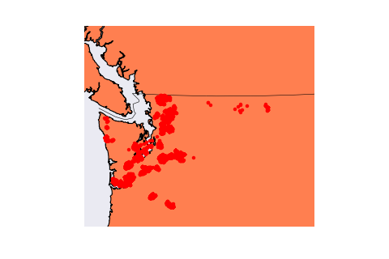

```python
from mpl_toolkits.basemap import Basemap
import matplotlib.pyplot as plt
import numpy as np

%matplotlib nbagg

#my_map = Basemap(projection='ortho',lon_0=-105,lat_0=40,resolution='l')

# make sure the value of resolution is a lowercase L,
#  for 'low', not a numeral 1
#my_map = Basemap(projection='ortho', lat_0=50, lon_0=-100,
#             resolution='l', area_thresh=500)

my_map2 = Basemap(llcrnrlon=-125, llcrnrlat=45, urcrnrlon=-115,
     urcrnrlat=51, projection='tmerc', lat_1=33, lat_2=45,
     lon_0=-119, lat_0=45, resolution='h', area_thresh=10000)

my_map2.drawcoastlines()
my_map2.drawcountries()
my_map2.fillcontinents(color='coral')

lon2 = np.array(walandslides.POINT_X)
lat2 = np.array(walandslides.POINT_Y)

#lon = np.array(walandslides.POINT_X_x)
#lat = np.array(walandslides.POINT_Y_x)

y2,x2 = my_map2(lon2, lat2)

#y,x = my_map2(lon, lat)

my_map2.plot(y2,x2, 'ro', markersize=4, markeredgecolor = 'k')
#my_map2.plot(y,x, 'ro', markersize=4, markeredgecolor = 'k')

#my_map2.plot(y,x, 'ro', markersize=4) # plots oregon data
#cbar = plt.colorbar(sc, shrink = .5)

plt.show()
```

```python
X = walandslides[feature_cols]
y = walandslides.LANDSLID_3
```

```python
y = pd.concat([y], axis=1)
```

### Final X and y - reduced to a size of 12241 observations

```python
X = pd.get_dummies(X)
X
```

|  | GEOLOGIC_1 | reacch_soi | LANDSLIDE1 | gradient_cat_1 | gradient_cat_2 | gradient_cat_3 | gradient_cat_4 | gradient_cat_5 | LAND_USE_Forestry related activities | LAND_USE_Road, railroad, trail | LAND_USE_Undisturbed | LAND_USE_Unknown | LAND_USE_Urban development |
| --- | --- | --- | --- | --- | --- | --- | --- | --- | --- | --- | --- | --- | --- |
| 1 | 29787 | 55856 | 12 | 0 | 0 | 1 | 0 | 0 | 0 | 1 | 0 | 0 | 0 |
| 2 | 33552 | 55805 | 3 | 0 | 0 | 0 | 0 | 1 | 0 | 1 | 0 | 0 | 0 |
| 4 | 32784 | 55804 | 12 | 1 | 0 | 0 | 0 | 0 | 0 | 1 | 0 | 0 | 0 |
| 5 | 30800 | 55837 | 3 | 0 | 0 | 0 | 1 | 0 | 0 | 1 | 0 | 0 | 0 |
| 6 | 30800 | 55837 | 12 | 0 | 0 | 1 | 0 | 0 | 0 | 0 | 0 | 0 | 1 |
| 7 | 30800 | 55837 | 12 | 0 | 0 | 1 | 0 | 0 | 0 | 0 | 0 | 0 | 1 |
| 12 | 32460 | 55960 | 11 | 0 | 0 | 0 | 0 | 1 | 1 | 0 | 0 | 0 | 0 |
| 13 | 31600 | 55960 | 12 | 0 | 0 | 0 | 1 | 0 | 0 | 1 | 0 | 0 | 0 |
| 14 | 31600 | 55960 | 11 | 0 | 0 | 0 | 0 | 1 | 1 | 0 | 0 | 0 | 0 |
| 15 | 31600 | 55960 | 12 | 0 | 0 | 0 | 1 | 0 | 0 | 1 | 0 | 0 | 0 |
| 16 | 31600 | 55960 | 12 | 0 | 0 | 1 | 0 | 0 | 0 | 1 | 0 | 0 | 0 |
| 17 | 31600 | 55960 | 12 | 0 | 0 | 0 | 0 | 1 | 1 | 0 | 0 | 0 | 0 |
| 18 | 31600 | 55960 | 11 | 0 | 0 | 0 | 0 | 1 | 1 | 0 | 0 | 0 | 0 |
| 19 | 31600 | 55960 | 3 | 0 | 0 | 0 | 0 | 1 | 1 | 0 | 0 | 0 | 0 |
| 21 | 31600 | 55960 | 3 | 0 | 0 | 0 | 0 | 1 | 1 | 0 | 0 | 0 | 0 |
| 22 | 31600 | 55960 | 3 | 0 | 0 | 0 | 0 | 1 | 1 | 0 | 0 | 0 | 0 |
| 23 | 31600 | 55960 | 11 | 0 | 0 | 0 | 0 | 1 | 1 | 0 | 0 | 0 | 0 |
| 26 | 31600 | 55960 | 3 | 0 | 0 | 0 | 0 | 1 | 1 | 0 | 0 | 0 | 0 |
| 27 | 27584 | 55803 | 3 | 0 | 1 | 0 | 0 | 0 | 1 | 0 | 0 | 0 | 0 |
| 28 | 27584 | 55803 | 3 | 0 | 0 | 0 | 1 | 0 | 1 | 0 | 0 | 0 | 0 |
| 29 | 27584 | 55803 | 12 | 0 | 0 | 1 | 0 | 0 | 1 | 0 | 0 | 0 | 0 |
| 31 | 27584 | 55960 | 3 | 0 | 0 | 0 | 1 | 0 | 1 | 0 | 0 | 0 | 0 |
| 32 | 27584 | 55960 | 12 | 0 | 0 | 0 | 0 | 1 | 1 | 0 | 0 | 0 | 0 |
| 33 | 27584 | 55960 | 12 | 0 | 0 | 0 | 0 | 1 | 1 | 0 | 0 | 0 | 0 |
| 34 | 27584 | 55960 | 12 | 0 | 0 | 0 | 0 | 1 | 1 | 0 | 0 | 0 | 0 |
| 35 | 31600 | 55960 | 11 | 0 | 0 | 0 | 0 | 1 | 1 | 0 | 0 | 0 | 0 |
| 36 | 36041 | 55852 | 3 | 0 | 0 | 0 | 0 | 1 | 0 | 0 | 1 | 0 | 0 |
| 37 | 36129 | 55960 | 3 | 0 | 0 | 0 | 0 | 1 | 0 | 1 | 0 | 0 | 0 |
| 38 | 34939 | 55960 | 3 | 0 | 0 | 0 | 0 | 1 | 0 | 0 | 1 | 0 | 0 |
| 39 | 34939 | 55960 | 3 | 0 | 0 | 0 | 0 | 1 | 0 | 0 | 1 | 0 | 0 |
| ... | ... | ... | ... | ... | ... | ... | ... | ... | ... | ... | ... | ... | ... |
| 52701 | 12444 | 212640 | 10 | 0 | 0 | 1 | 0 | 0 | 1 | 0 | 0 | 0 | 0 |
| 52702 | 8321 | 56179 | 12 | 0 | 0 | 0 | 1 | 0 | 0 | 0 | 0 | 1 | 0 |
| 52707 | 49011 | 54691 | 12 | 0 | 0 | 0 | 1 | 0 | 1 | 0 | 0 | 0 | 0 |
| 52709 | 2471 | 56772 | 11 | 0 | 0 | 0 | 0 | 1 | 1 | 0 | 0 | 0 | 0 |
| 52719 | 20311 | 212640 | 10 | 0 | 0 | 0 | 0 | 1 | 1 | 0 | 0 | 0 | 0 |
| 52729 | 36939 | 55073 | 11 | 0 | 0 | 1 | 0 | 0 | 0 | 1 | 0 | 0 | 0 |
| 52731 | 19032 | 212640 | 11 | 0 | 0 | 0 | 1 | 0 | 0 | 0 | 1 | 0 | 0 |
| 52732 | 50336 | 54713 | 10 | 0 | 1 | 0 | 0 | 0 | 1 | 0 | 0 | 0 | 0 |
| 52734 | 39680 | 54608 | 13 | 0 | 0 | 1 | 0 | 0 | 0 | 0 | 0 | 1 | 0 |
| 52737 | 8558 | 212640 | 12 | 0 | 0 | 1 | 0 | 0 | 1 | 0 | 0 | 0 | 0 |
| 52739 | 50906 | 54637 | 3 | 0 | 1 | 0 | 0 | 0 | 1 | 0 | 0 | 0 | 0 |
| 52745 | 26155 | 54928 | 10 | 1 | 0 | 0 | 0 | 0 | 1 | 0 | 0 | 0 | 0 |
| 52757 | 39680 | 54716 | 10 | 0 | 1 | 0 | 0 | 0 | 0 | 0 | 0 | 1 | 0 |
| 52760 | 3014 | 56626 | 12 | 0 | 0 | 1 | 0 | 0 | 1 | 0 | 0 | 0 | 0 |
| 52761 | 21185 | 212640 | 12 | 0 | 0 | 0 | 0 | 1 | 0 | 0 | 1 | 0 | 0 |
| 52765 | 46809 | 54688 | 11 | 0 | 0 | 1 | 0 | 0 | 1 | 0 | 0 | 0 | 0 |
| 52766 | 37048 | 55281 | 12 | 1 | 0 | 0 | 0 | 0 | 1 | 0 | 0 | 0 | 0 |
| 52774 | 2223 | 56772 | 10 | 1 | 0 | 0 | 0 | 0 | 1 | 0 | 0 | 0 | 0 |
| 52779 | 8564 | 212640 | 12 | 0 | 0 | 1 | 0 | 0 | 1 | 0 | 0 | 0 | 0 |
| 52783 | 41016 | 55756 | 12 | 0 | 0 | 1 | 0 | 0 | 0 | 0 | 0 | 1 | 0 |
| 52785 | 26143 | 54784 | 11 | 0 | 1 | 0 | 0 | 0 | 1 | 0 | 0 | 0 | 0 |
| 52786 | 57053 | 168389 | 10 | 0 | 0 | 1 | 0 | 0 | 1 | 0 | 0 | 0 | 0 |
| 52787 | 39680 | 54592 | 12 | 0 | 0 | 1 | 0 | 0 | 0 | 0 | 0 | 1 | 0 |
| 52789 | 46809 | 55560 | 12 | 1 | 0 | 0 | 0 | 0 | 0 | 1 | 0 | 0 | 0 |
| 52790 | 51267 | 54636 | 12 | 0 | 0 | 1 | 0 | 0 | 1 | 0 | 0 | 0 | 0 |
| 52791 | 14306 | 212640 | 11 | 0 | 0 | 0 | 0 | 1 | 0 | 1 | 0 | 0 | 0 |
| 52796 | 8558 | 212640 | 12 | 0 | 1 | 0 | 0 | 0 | 1 | 0 | 0 | 0 | 0 |
| 52798 | 2471 | 56772 | 3 | 1 | 0 | 0 | 0 | 0 | 1 | 0 | 0 | 0 | 0 |
| 52799 | 21181 | 212640 | 11 | 0 | 0 | 0 | 0 | 1 | 0 | 0 | 1 | 0 | 0 |
| 52806 | 8558 | 56269 | 12 | 0 | 0 | 1 | 0 | 0 | 1 | 0 | 0 | 0 | 0 |

12241 rows × 13 columns

```python
#y = pd.DataFrame(y)
```

### Initial breakdown of gradient by degree (categorized)

```python
gradient_pd = walandslides['gradient_cat'].value_counts()
```

```python
import matplotlib
%matplotlib nbagg

gradient_pd.plot(kind='bar');
```

[output not shown]

### Initial breakdown of slope morphology

```python
slopemorp_pd = walandslides['SLOPE_MORP'].value_counts()
```

```python
slopemorp_pd.plot(kind='bar');
```

[output not shown]

### Initial breakdown of geology

```python
geology_pd = walandslides['GEOLOGIC_U'].value_counts()
```

```python
geology_pd.plot(kind='bar');
```

[output not shown]

### Initial breakdown of land use

```python
landuse_pd = walandslides['LAND_USE'].value_counts()
```

```python
landuse_pd.plot(kind='bar');
```

[output not shown]

```python
landslidetype_pd = walandslides['LANDSLIDE1'].value_counts()
```

```python
import matplotlib
%matplotlib nbagg
landslidetype_pd.plot(kind='bar');
```

[output not shown]

```python
landslid3_pd = walandslides['LANDSLID_3'].value_counts()
```

```python
import matplotlib
%matplotlib nbagg
landslid3_pd.plot(kind='bar');
```

[output not shown]

### Landslide liklihood counts (0=questionable,1=probable, 2=certain)

```python
y['LANDSLID_3'].value_counts()
```

```
2    7501
1    3806
0     934
dtype: int64
```

```python
import seaborn as sns
import matplotlib.pyplot as plt
%matplotlib inline
```

### Geology compared to other feature variables

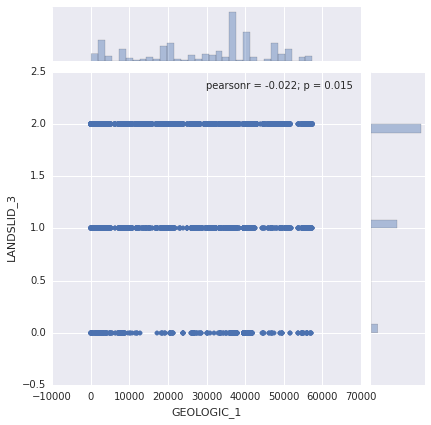

```python
sns.jointplot(x="GEOLOGIC_1", y="LANDSLID_3", data=walandslides);
```

### Gradient compared to other feature variables

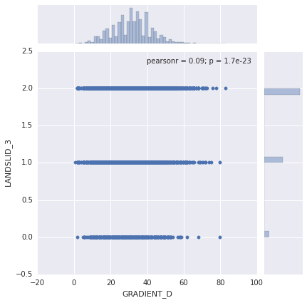

```python
sns.jointplot(x="GRADIENT_D", y="LANDSLID_3", data=walandslides);
```

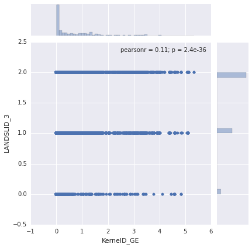

```python
sns.jointplot(x="KernelD_GE", y="LANDSLID_3", data=walandslides);
```

## Box plot showing how slope morphology varies by landslide type, for differing landslide liklihoods. (0=questionable, 1=probable, 2=certain)

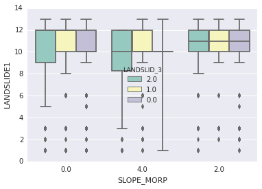

```python
ax = sns.boxplot(x="SLOPE_MORP", y="LANDSLIDE1", hue="LANDSLID_3",
     data=walandslides, palette="Set3")
```

## Linear relationship between slope morphology and landslide type, conditioned for differing landslide liklihoods. (0=questionable, 1=probable, 2=certain),

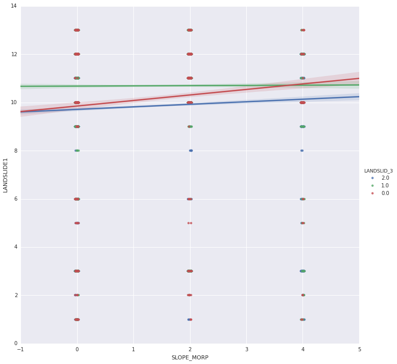

```python
sns.lmplot(x="SLOPE_MORP", y="LANDSLIDE1", hue="LANDSLID_3",
     data=walandslides, ci=70, aspect=1, x_jitter=.03, size=10)
```

## Box plot showing how gradient varies by slope morphology, for differing landslide liklihoods. (0=questionable, 1=probable, 2=certain)

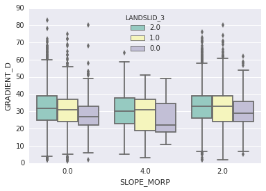

```python
ax = sns.boxplot(x="SLOPE_MORP", y="GRADIENT_D", hue="LANDSLID_3",
     data=walandslides, palette="Set3")
```

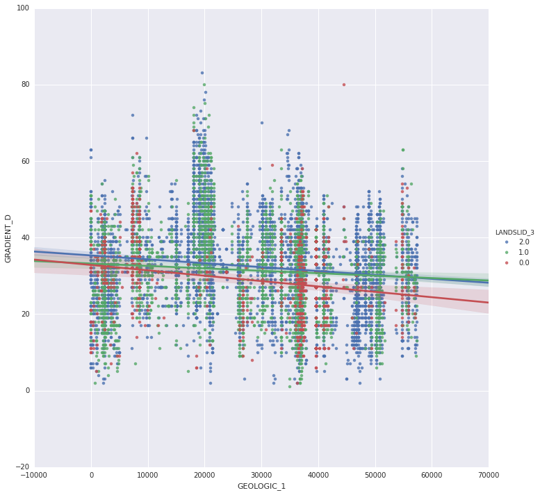

```python
sns.lmplot(x="GEOLOGIC_1", y="GRADIENT_D", hue="LANDSLID_3",
     data=walandslides, ci=100, aspect=1, x_jitter=.03, size=10)
```

[figure not shown]

```python
ax = sns.boxplot(x="GEOLOGIC_1", y="GRADIENT_D", hue="LANDSLID_3",
     data=walandslides, palette="Set3")
```

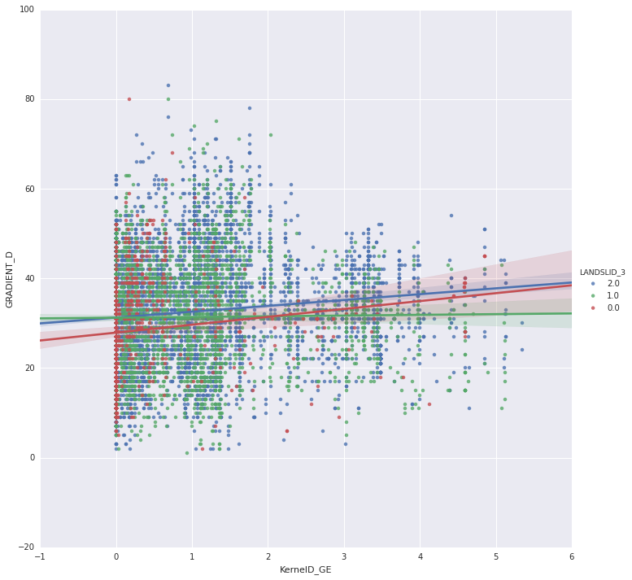

```python
sns.lmplot(x="KernelD_GE", y="GRADIENT_D", hue="LANDSLID_3",
     data=walandslides, ci=100, aspect=1, x_jitter=0, size=10)
```

## run train test split

```python
X_train, X_test, y_train, y_test = train_test_split(X, y, random_state=99)
```

## Begin Model analysis

### Calculate Null Accuracy

```python
#y_test.value_counts()
```

```python
# this works regardless of the number of classes
y['LANDSLID_3'].value_counts().head(1) / len(y['LANDSLID_3'])
```

```
2    0.612777
dtype: float64
```

### 10-fold cross-validation with logistic regression

```python
y = np.ravel(y) #flatten y for appropriate dimensionality for interation with X
```

```python
logregtime1 = %%timeit -o 1 + 2

# 10-fold cross-validation with logistic regression
from sklearn.linear_model import LogisticRegression
logreg = LogisticRegression()
logreg_scores_mean = cross_val_score(logreg, X, y, cv=KFold(X.shape[0], n_folds=10, shuffle=True), scoring='accuracy').mean()
print logreg_scores_mean
```

```
10000000 loops, best of 3: 29.7 ns per loop
0.612776310524
```

```python
logreg_scores = cross_val_score(logreg, X, y, cv=KFold(X.shape[0], n_folds=10, shuffle=True), scoring='accuracy')
```

### Naive Bayes Multinomial

```python
nbmtime1 = %%timeit -o 1 + 2
from sklearn.naive_bayes import MultinomialNB
nbm = MultinomialNB()
nbm.fit(X, y)
MultinomialNB(alpha=1.0, class_prior=None, fit_prior=True)
nbm_scores = cross_val_score(nbm, X, y, cv=KFold(X.shape[0], n_folds=10, shuffle=True), scoring='accuracy')
print nbm_scores
#print(clf.predict(X[2:3]))
```

```
The slowest run took 40.17 times longer than the fastest. This could mean that an intermediate result is being cached
10000000 loops, best of 3: 29.7 ns per loop
[ 0.46938776  0.33088235  0.45669935  0.47222222  0.44199346  0.33496732
  0.31535948  0.46895425  0.44934641  0.45996732]
```

```python
mean_score = nbm_scores.mean()
std_dev = nbm_scores.std()
std_error = nbm_scores.std() / math.sqrt(nbm_scores.shape[0])
ci =  2.262 * std_error
lower_bound = mean_score - ci
upper_bound = mean_score + ci

print "Multinomial NB Score is %f +/-  %f" % (mean_score, ci)
print "Multinomial NB AUC is "
print '95 percent probability that if this experiment were repeated over and over the average score would be between %f and %f' % (lower_bound, upper_bound)
```

[output not shown]

### 10-fold cross-validation with K Nearest Neighbor

```python
from sklearn.neighbors import KNeighborsClassifier
knn = KNeighborsClassifier(n_neighbors=9)
scores = cross_val_score(knn, X, y, cv=10, scoring='accuracy')
knn_scores = cross_val_score(knn, X, y, cv=KFold(X.shape[0], n_folds=10, shuffle=True), scoring='accuracy')
print knn_scores
```

```
[ 0.70367347  0.7001634   0.69117647  0.70343137  0.66830065  0.71323529
  0.67401961  0.71486928  0.70261438  0.71977124]
```

```python
mean_score = knn_scores.mean()
std_dev = knn_scores.std()
std_error = knn_scores.std() / math.sqrt(knn_scores.shape[0])
ci =  2.262 * std_error
lower_bound = mean_score - ci
upper_bound = mean_score + ci

print "K nearest neighbhor Score is %f +/-  %f" % (mean_score, ci)
print '95 percent probability that if this experiment were repeated over and over the average score would be between %f and %f' % (lower_bound, upper_bound)
```

```
K nearest neighbhor Score is 0.699126 +/-  0.011466
95 percent probability that if this experiment were repeated over and over the average score would be between 0.687660 and 0.710591
```

### Search for an optimal value of K for KNN

```python
# search for an optimal value of K for KNN
k_range = range(1, 31)
k_scores = []
for k in k_range:
    knn = KNeighborsClassifier(n_neighbors=k)
    scores = cross_val_score(knn, X, y, cv=10, scoring='accuracy')
    k_scores.append(scores.mean())
print k_scores
```

[output not shown]

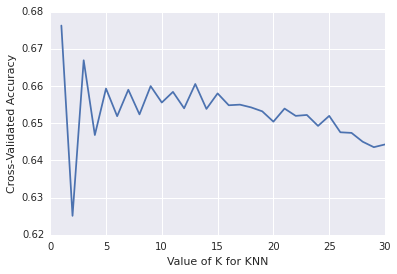

```python
import matplotlib.pyplot as plt
%matplotlib inline

# plot the value of K for KNN (x-axis) versus the cross-validated accuracy (y-axis)
plt.plot(k_range, k_scores)
plt.xlabel('Value of K for KNN')
plt.ylabel('Cross-Validated Accuracy')
```

### Decision Tree - Fit a classification tree with an initial max_depth=3 on all data

```python
from sklearn.tree import DecisionTreeClassifier
treeclf = DecisionTreeClassifier(max_depth=3, random_state=1)
scores = cross_val_score(treeclf, X, y, cv=KFold(X.shape[0], n_folds=10, shuffle=True), scoring='accuracy')
treeclf.fit(X, y)
print scores
```

```
[ 0.67591837  0.65604575  0.66911765  0.65196078  0.66911765  0.67075163
  0.67810458  0.67647059  0.64624183  0.66013072]
```

### MODEL 6: Decision Tree - search for an optimal gamma/depth for Decision Tree

```python
from sklearn.tree import DecisionTreeClassifier
t_range = range(1, 100)
t_scores = []
for k in t_range:
    clf = DecisionTreeClassifier(max_depth=k)
    scores = cross_val_score(clf, X, y, cv=KFold(X.shape[0], n_folds=10, shuffle=True), scoring='accuracy')
    t_scores.append(scores.mean())
print t_scores
```

[output not shown]

### MODEL 6: Decision Tree - Plot accuracy of cross validation runs vs. values of depth

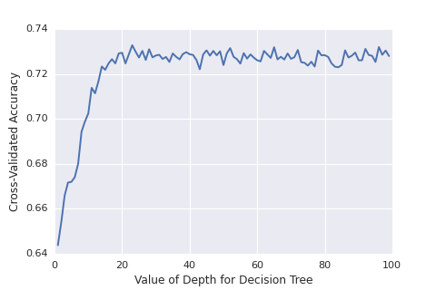

```python
import matplotlib
%matplotlib nbagg
plt.plot(t_range, t_scores)
plt.xlabel('Value of Depth for Decision Tree')
plt.ylabel('Cross-Validated Accuracy')
```

### MODEL 6: Decision Tree - Model optimization results:

```python
clftime1 = %%timeit -o 1 + 2
from sklearn.tree import DecisionTreeClassifier
treeclf = DecisionTreeClassifier(max_depth=3, random_state=1)
treeclf_scores = cross_val_score(clf, X, y, cv=KFold(X.shape[0], n_folds=10, shuffle=True), scoring='accuracy')
treeclf.fit(X, y)
print treeclf_scores
```

```
10000000 loops, best of 3: 29.7 ns per loop
[ 0.72571429  0.73120915  0.7369281   0.71650327  0.73202614  0.75163399
  0.71405229  0.72303922  0.70751634  0.73937908]
```

```python
print("Accuracy: %0.2f (+/- %0.2f)" % (treeclf_scores.mean(), treeclf_scores.std() * 2))
```

```
Accuracy: 0.73 (+/- 0.03)
```

```python
from StringIO import StringIO
tree_landslide = StringIO()

from sklearn.tree import DecisionTreeClassifier, export_graphviz
export_graphviz(treeclf, out_file=tree_landslide)
```

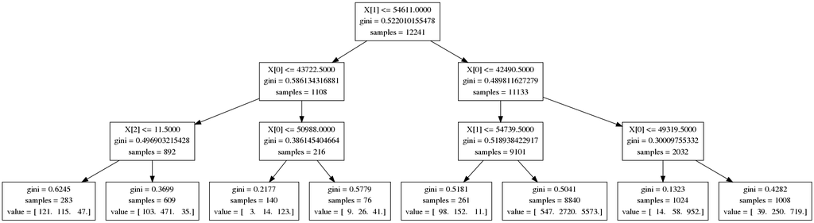

```python
graph = pydot.graph_from_dot_data(tree_landslide.getvalue())
Image(graph.create_png())
```

```python
### Random Forest
```

```python
from sklearn.ensemble import RandomForestClassifier
rfreg = RandomForestClassifier()
rfreg
```

```
RandomForestClassifier(bootstrap=True, class_weight=None, criterion='gini',
            max_depth=None, max_features='auto', max_leaf_nodes=None,
            min_samples_leaf=1, min_samples_split=2,
            min_weight_fraction_leaf=0.0, n_estimators=10, n_jobs=1,
            oob_score=False, random_state=None, verbose=0,
            warm_start=False)
```

```python
# list of values to try for n_estimators
estimator_range = range(10, 310, 10)

# list to store the average RMSE for each value of n_estimators
RMSE_scores = []

# use 5-fold cross-validation with each value of n_estimators (WARNING: SLOW!)
for estimator in estimator_range:
    rfreg = RandomForestClassifier(n_estimators=estimator, random_state=1)
    MSE_scores = cross_val_score(rfreg, X, y, cv=5, scoring='mean_squared_error')
    RMSE_scores.append(np.mean(np.sqrt(-MSE_scores)))
```

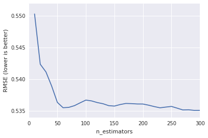

```python
# plot n_estimators (x-axis) versus RMSE (y-axis)
plt.plot(estimator_range, RMSE_scores)
plt.xlabel('n_estimators')
plt.ylabel('RMSE (lower is better)')
```

```python
# show the best RMSE and the corresponding max_features
sorted(zip(RMSE_scores, estimator_range))[0]
```

```
(0.53512359275909394, 290)
```

```python
# list of values to try for max_features
feature_range = range(1, len(feature_cols)+1)

# list to store the average RMSE for each value of max_features
RMSE_scores = []

# use 10-fold cross-validation with each value of max_features (WARNING: SLOW!)
for feature in feature_range:
    rfreg = RandomForestRegressor(n_estimators=30, max_features=feature, random_state=1)
    MSE_scores = cross_val_score(rfreg, X, y, cv=10, scoring='mean_squared_error')
    RMSE_scores.append(np.mean(np.sqrt(-MSE_scores)))
```

[figure not shown]

```python
# plot max_features (x-axis) versus RMSE (y-axis)
plt.plot(feature_range, RMSE_scores)
plt.xlabel('max_features')
plt.ylabel('RMSE (lower is better)')
```

```python
# show the best RMSE and the corresponding max_features
sorted(zip(RMSE_scores, feature_range))[0]
```

```
(0.48484624804746196, 2)
```

```python
# max_features=2 is best and n_estimators=150 is sufficiently large
rfreg = RandomForestRegressor(n_estimators=30, max_features=2, oob_score=True, random_state=1)
rfreg.fit(X, y)
```

```
RandomForestRegressor(bootstrap=True, criterion='mse', max_depth=None,
           max_features=2, max_leaf_nodes=None, min_samples_leaf=1,
           min_samples_split=2, min_weight_fraction_leaf=0.0,
           n_estimators=30, n_jobs=1, oob_score=True, random_state=1,
           verbose=0, warm_start=False)
```

```python
# compute feature importances
pd.DataFrame({'feature':feature_cols, 'importance':rfreg.feature_importances_}).sort('importance')
```

[output not shown]

```python
# compute the out-of-bag R-squared score
rfreg.oob_score_
```

```
0.41693974223699615
```

```python
# set a threshold for which features to include
print rfreg.transform(X, threshold=0.1).shape
print rfreg.transform(X, threshold='mean').shape
print rfreg.transform(X, threshold='median').shape
```

```
(12241, 4)
(12241, 4)
(12241, 6)
```

```python
# create a new feature matrix that only includes important features
X_important = rfreg.transform(X, threshold='mean')
```

```python
# check the RMSE for a Random Forest that only includes important features
rfreg = RandomForestRegressor(n_estimators=30, max_features=2, random_state=1)
scores = cross_val_score(rfreg, X_important, y, cv=10, scoring='mean_squared_error')
np.mean(np.sqrt(-scores))
```

```
0.49999203916999602
```

### Bootstrap aggregation of decision tree

```python
bag_scores = []

bag_range = range(1, 100)

for k in bag_range:
    bag_clf = BaggingClassifier(treeclf, n_estimators=k, max_samples=1.0, max_features=5, bootstrap = False, bootstrap_features = True, random_state=42)
    bag_clf.fit(X, y)
    MSE_scores = cross_val_score(bag_clf, X, y, cv=KFold(X.shape[0], n_folds=10, shuffle=True), scoring='mean_squared_error')
    bag_scores.append(bag_clf_scores.mean())
    RMSE_scores.append(np.mean(np.sqrt(-MSE_scores)))
print bag_clf_scores
```

[output not shown]

```python
bag_clf_scores = cross_val_score(bag_clf, X, y, cv=KFold(X.shape[0], n_folds=10, shuffle=True), scoring='accuracy')
```

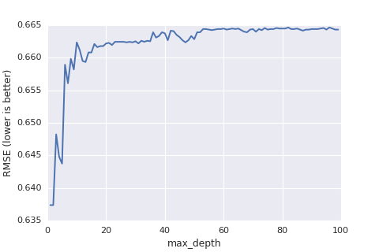

```python
import matplotlib
%matplotlib nbagg
# plot max_depth (x-axis) versus RMSE (y-axis)
plt.plot(bag_range, bag_scores)
plt.xlabel('max_depth')
plt.ylabel('RMSE (lower is better)')
```

### Gaussian Naive Bayes

```python
from sklearn import datasets
from sklearn.naive_bayes import GaussianNB
gnb = GaussianNB()
y_pred = gnb.fit(X, y).predict(X)
print("Number of mislabeled points out of a total %d points : %d"
       % (X.shape[0],(y != y_pred).sum()))
```

```
Number of mislabeled points out of a total 12241 points : 10953
```

### Multinomial Naive Bayes

```python
from sklearn import datasets
from sklearn.naive_bayes import MultinomialNB
gnb = MultinomialNB()
y_pred = gnb.fit(X, y).predict(X)
print("Number of mislabeled points out of a total %d points : %d"
       % (X.shape[0],(y != y_pred).sum()))
```

```
Number of mislabeled points out of a total 12241 points : 6635
```

### Bernoulli Naive Bayes

```python
from sklearn import datasets
from sklearn.naive_bayes import BernoulliNB
gnb = BernoulliNB()
y_pred = gnb.fit(X, y).predict(X)
print("Number of mislabeled points out of a total %d points : %d"
       % (X.shape[0],(y != y_pred).sum()))
```

```
Number of mislabeled points out of a total 12241 points : 4691
```

```python
y = pd.DataFrame(y)
```

[output not shown]

12241 rows × 1 columns

```python
import numpy as np

# sigmoid function
def nonlin(x,deriv=False):
    if(deriv==True):
        return x*(1-x)
    return 1/(1+np.exp(-x))


# seed random numbers to make calculation
# deterministic (just a good practice)
np.random.seed(1)

# initialize weights randomly with mean 0
syn0 = 2*np.random.random((11,1)) - 1

for iter in xrange(10000):

    # forward propagation
    l0 = X
    l1 = nonlin(np.dot(l0,syn0))

    # how much did we miss?
    l1_error = y - l1

    # multiply how much we missed by the
    # slope of the sigmoid at the values in l1
    l1_delta = l1_error * nonlin(l1,True)

    # update weights
    syn0 += np.dot(l0.T,l1_delta)

print "Output After Training:"
print l1
```

[output not shown]

```python
y
```

[output not shown]

```python
l1 = pd.DataFrame(l1)
```

```python
l1
```

[output not shown]

12241 rows × 1 columns

```python
l1.columns = ['LANDSLID_3']
```

```python
l1
```

|  | LANDSLID_3 |
| --- | --- |
| 0 | 1 |
| 1 | 1 |
| 2 | 1 |
| 3 | 1 |
| 4 | 1 |
| 5 | 1 |
| 6 | 1 |
| 7 | 1 |
| 8 | 1 |
| 9 | 1 |
| 10 | 1 |
| 11 | 1 |
| 12 | 1 |
| 13 | 1 |
| 14 | 1 |
| 15 | 1 |
| 16 | 1 |
| 17 | 1 |
| 18 | 1 |
| 19 | 1 |
| 20 | 1 |
| 21 | 1 |
| 22 | 1 |
| 23 | 1 |
| 24 | 1 |
| 25 | 1 |
| 26 | 1 |
| 27 | 1 |
| 28 | 1 |
| 29 | 1 |
| ... | ... |
| 12211 | 1 |
| 12212 | 1 |
| 12213 | 1 |
| 12214 | 1 |
| 12215 | 1 |
| 12216 | 1 |
| 12217 | 1 |
| 12218 | 1 |
| 12219 | 1 |
| 12220 | 1 |
| 12221 | 1 |
| 12222 | 1 |
| 12223 | 1 |
| 12224 | 1 |
| 12225 | 1 |
| 12226 | 1 |
| 12227 | 1 |
| 12228 | 1 |
| 12229 | 1 |
| 12230 | 1 |
| 12231 | 1 |
| 12232 | 1 |
| 12233 | 1 |
| 12234 | 1 |
| 12235 | 1 |
| 12236 | 1 |
| 12237 | 1 |
| 12238 | 1 |
| 12239 | 1 |
| 12240 | 1 |

12241 rows × 1 columns

```python
l1['LANDSLID_3'].value_counts()
```

```
1    12241
dtype: int64
```

```python
nonlin(np.dot(l0,syn0))
```

```
array([[ 1.],
       [ 1.],
       [ 1.],
       ...,
       [ 1.],
       [ 1.],
       [ 1.]])
```

```python
url = "http://129.101.160.58:5000/api"
data = json.dumps({'cool':1, 'useful':8, 'funny':2})
r = requests.post(url, data)

print r.json()
```

[output not shown]